# MA415 Project 1

Lin Li, Lingjia Zhang, Zirui Liu

## Background

According to the CNN news, apprehensions at the US-Mexico border reached the historic low rate in April 2017, and have a continuing downward trend during the first few months of the Trump administration. The drop of the apprehension rate was interpreted as the sign of “President Donald Trump’s rhetoric and aggressive push to enforce immigration laws is having an effect.” Through this project, we want to analyze by using past data to estimate whether the declining rate of apprehension relates to the President Donald’s new law.

## Datasets

- BP Apprehensions 2010.csv
- BP Apprehensions 2017.csv
- BP monthly summaries.csv

## Data Visualization

1. Based on csv files, we compare the apprehensions by sectors and months between 2010 and 2017. First of all, we sum up apprehensions by sectors and create the following plot.

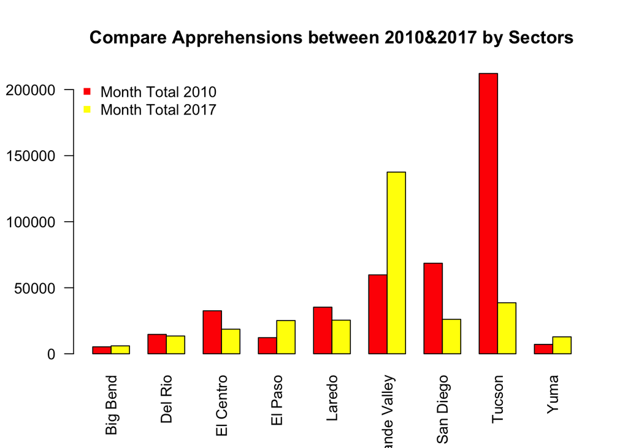

```r
plot_by_sectors(13)
```

2. Second of all, we sum up apprehensions by months and create the following plot.

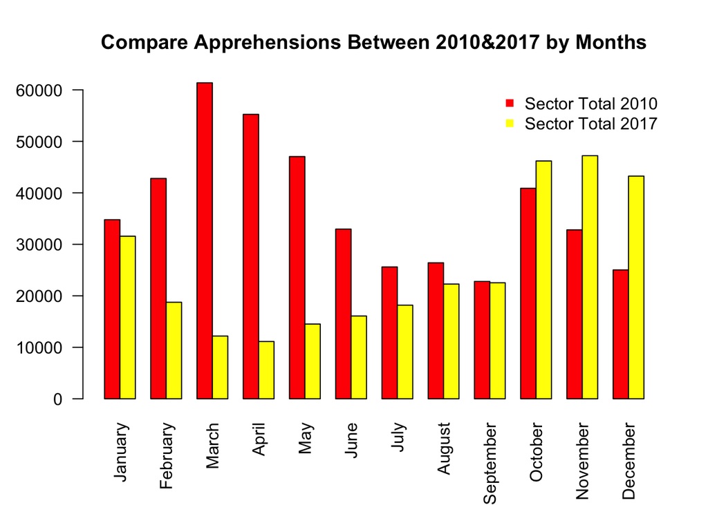

```r
plot_by_months(10)
```

Based on these two graphs, it is easy to conclude that in 2010, Tucson has the most apprehensions. In 2017, Rio Grande Valley has the most apprehensions. In 2010, from March to May, there are most apprehensions. In 2017, from October to December, there are most apprehensions.

# Statistic Analysis

## First problem

Use simple statistical tests linke those demonstrated in class to compare the sector with the most apprehensions for 2010 and with the sector with the most apprehensions in 2017. Has there been a change in the maximum?

```r
#In 2010, the sector that has most apprehensions is Tucson
most_2010 <- match(max(T2010[1:9,13]), T2010[1:9,13])
rownames(T2010)[most_2010]
```

```
## [1] "Tucson"
```

```r
#In 2017, the sector that has most apprehensions is Rio Grande Valley
most_2017 <- match(max(T2017[1:9,13]), T2017[1:9,13])
rownames(T2017)[most_2017]
```

```
## [1] "Rio Grande Valley"
```

To evaluate wheter the most apprehensions between 2010(Tucson) and 2017(Rio Grande Valley),we have following null hypothesis and alternative hypothesis:

$$H_{0}:\mu _{Tucson, 2010} - \mu _{RGV, 2017} = 0$$
$$H_{a}:\mu _{Tucson, 2010} - \mu _{RGV, 2017} \neq 0$$

```
##
##  Welch Two Sample t-test
##
## data:  T2010_Tuson and T2017_RGV
## t = 1.9547, df = 21.973, p-value = 0.06346
## alternative hypothesis: true difference in means is not equal to 0
## 95 percent confidence interval:
##   -379.5935 12819.5935
## sample estimates:
## mean of x mean of y
##   17683.5   11463.5
```

From t-test, we get p-value = 0.06346 > 0.05, and we fail to reject the null hypothesis. At significance level of 5%, the mean of apprehension of Tucson in 2010 is equal to the mean of apprehension of Rio Grande Valley in 2017. Thus, there is no significant difference between the maximum of apprehensions by secoter in 2010 and 2017.

## Second problem

From the grpah, we know that in 2010, March, April, and May are ranking top 3. In 2017, November, October, and December are ranking top 3. The statistic analysis we want to evaluate is whether the mean of 3-month highest apprehensions has changed.

```r
# In 2010, March, April,and May have the most apprehensions
top3_2010 <- order(T2010[10,1:12], decreasing = TRUE)[1:3]
colnames(T2010)[top3_2010]
```

```
## [1] "March" "April" "May"
```

```r
# In 2017, November, October,and December have the most apprehensions
top3_2017 <- order(T2017[10,1:12], decreasing = TRUE)[1:3]
colnames(T2017)[top3_2017]
```

```
## [1] "November" "October"  "December"
```

Null hypothesis and alternative hypothesis:
$$H_{0}:\mu _{3 months, 2010} - \mu _{3 months, 2017} = 0$$
$$H_{a}:\mu _{3 months, 2010} - \mu _{3 months, 2017} \neq 0$$

[output not shown]

## Time series

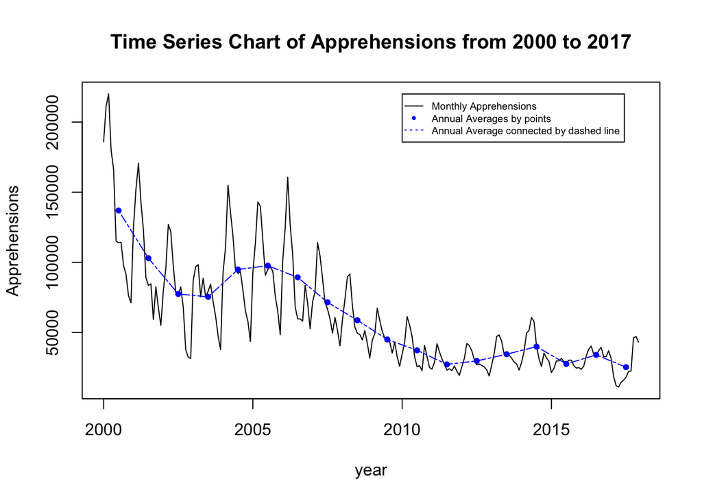